# Vaex introduction in 11 minutes

## DataFrame

Central to Vaex is the DataFrame (similar, but more efficient than a Pandas DataFrame), and we often use the variable `df` to represent it. A DataFrame is an efficient representation for a large tabular dataset, and has:

- A number of columns, say `x`, `y` and `z`, which are:
  - Backed by a Numpy array;
  - Wrapped by an expression system e.g. `df.x`, `df['x']` or `df.col.x` is an Expression;
  - Columns/expression can perform lazy computations, e.g. `df.x * np.sin(df.y)` does nothing, until the result is needed.
- A set of virtual columns, columns that are backed by a (lazy) computation, e.g. `df['r'] = df.x/df.y`
- A set of selections, that can be used to explore the dataset, e.g. `df.select(df.x < 0)`
- Filtered DataFrames, that does not copy the data, `df_negative = df[df.x < 0]`

Lets start with an example dataset, which is included in Vaex.

```python
import vaex
df = vaex.example()
df  # Since this is the last statement in a cell, it will print the DataFrame in a nice HTML format.
```

| # | id | x | y | z | vx | vy | vz | E | L | Lz | FeH |
| --- | --- | --- | --- | --- | --- | --- | --- | --- | --- | --- | --- |
| *0* | 0 | 1.2318683862686157 | -0.39692866802215576 | -0.598057746887207 | 301.1552734375 | 174.05947875976562 | 27.42754554748535 | -149431.40625 | 407.38897705078125 | 333.9555358886719 | -1.0053852796554565 |
| *1* | 23 | -0.16370061039924622 | 3.654221296310425 | -0.25490644574165344 | -195.00022888183594 | 170.47216796875 | 142.5302276611328 | -124247.953125 | 890.2411499023438 | 684.6676025390625 | -1.7086670398712158 |
| *2* | 32 | -2.120255947113037 | 3.326052665710449 | 1.7078403234481812 | -48.63423156738281 | 171.6472930908203 | -2.079437255859375 | -138500.546875 | 372.2410888671875 | -202.17617797851562 | -1.8336141109466553 |
| *3* | 8 | 4.7155890464782715 | 4.5852508544921875 | 2.2515437602996826 | -232.42083740234375 | -294.850830078125 | 62.85865020751953 | -60037.0390625 | 1297.63037109375 | -324.6875 | -1.4786882400512695 |
| *4* | 16 | 7.21718692779541 | 11.99471664428711 | -1.064562201499939 | -1.6891745328903198 | 181.329345703125 | -11.333610534667969 | -83206.84375 | 1332.7989501953125 | 1328.948974609375 | -1.8570483922958374 |
| ... | ... | ... | ... | ... | ... | ... | ... | ... | ... | ... | ... |
| *329,995* | 21 | 1.9938701391220093 | 0.789276123046875 | 0.22205990552902222 | -216.92990112304688 | 16.124420166015625 | -211.244384765625 | -146457.4375 | 457.72247314453125 | 203.36758422851562 | -1.7451677322387695 |
| *329,996* | 25 | 3.7180912494659424 | 0.721337616443634 | 1.6415337324142456 | -185.92160034179688 | -117.25082397460938 | -105.4986572265625 | -126627.109375 | 335.0025634765625 | -301.8370056152344 | -0.9822322130203247 |
| *329,997* | 14 | 0.3688507676124573 | 13.029608726501465 | -3.633934736251831 | -53.677146911621094 | -145.15771484375 | 76.70909881591797 | -84912.2578125 | 817.1375732421875 | 645.8507080078125 | -1.7645612955093384 |
| *329,998* | 18 | -0.11259264498949051 | 1.4529125690460205 | 2.168952703475952 | 179.30865478515625 | 205.79710388183594 | -68.75872802734375 | -133498.46875 | 724.000244140625 | -283.6910400390625 | -1.8808952569961548 |
| *329,999* | 4 | 20.796220779418945 | -3.331387758255005 | 12.18841552734375 | 42.69000244140625 | 69.20479583740234 | 29.54275131225586 | -65519.328125 | 1843.07470703125 | 1581.4151611328125 | -1.1231083869934082 |

### Columns

The above preview shows that this dataset contains $> 300,000$ rows, and columns named x ,y, z (positions), vx, vy, vz (velocities), E (energy), L (angular momentum), and an id (subgroup of samples). When we print out a column, we can see that it is not a Numpy array, but an Expression.

```python
df.x
# df.col.x or df['x'] are equivalent, but df.x may be preferred
# because it is more tab completion friendly or programming friendly respectively
```

```
Expression = x
Length: 330,000 dtype: float32 (column)
---------------------------------------
     0    1.23187
     1  -0.163701
     2   -2.12026
     3    4.71559
     4    7.21719
       ...
329995    1.99387
329996    3.71809
329997   0.368851
329998  -0.112593
329999    20.7962
```

One can use the `.values` method to get an in-memory representation of an expression. The same method can be applied to a DataFrame as well.

```python
df.x.values
```

```
array([ 1.2318684 , -0.16370061, -2.120256  , ...,  0.36885077,
       -0.11259264, 20.79622   ], dtype=float32)
```

Most Numpy functions (ufuncs) can be performed on expressions, and will not result in a direct result, but in a new expression.

```python
import numpy as np
np.sqrt(df.x**2 + df.y**2 + df.z**2)
```

```
Expression = sqrt((((x ** 2) + (y ** 2)) + (z ** 2)))
Length: 330,000 dtype: float32 (expression)
-------------------------------------------
     0  1.42574
     1  3.66676
     2  4.29824
     3  6.95203
     4   14.039
      ...
329995  2.15587
329996  4.12785
329997  13.5319
329998  2.61304
329999  24.3339
```

### Virtual columns

Sometimes it is convenient to store an expression as a column. We call this a virtual column since it does not take up any memory, and is computed on the fly when needed. A virtual column is treated just as a normal column.

```python
df['r'] = np.sqrt(df.x**2 + df.y**2 + df.z**2)
df[['x', 'y', 'z', 'r']]
```

| # | x | y | z | r |
| --- | --- | --- | --- | --- |
| *0* | 1.2318683862686157 | -0.39692866802215576 | -0.598057746887207 | 1.425736665725708 |
| *1* | -0.16370061039924622 | 3.654221296310425 | -0.25490644574165344 | 3.666757345199585 |
| *2* | -2.120255947113037 | 3.326052665710449 | 1.7078403234481812 | 4.298235893249512 |
| *3* | 4.7155890464782715 | 4.5852508544921875 | 2.2515437602996826 | 6.952032566070557 |
| *4* | 7.21718692779541 | 11.99471664428711 | -1.064562201499939 | 14.03902816772461 |
| ... | ... | ... | ... | ... |
| *329,995* | 1.9938701391220093 | 0.789276123046875 | 0.22205990552902222 | 2.155872344970703 |
| *329,996* | 3.7180912494659424 | 0.721337616443634 | 1.6415337324142456 | 4.127851963043213 |
| *329,997* | 0.3688507676124573 | 13.029608726501465 | -3.633934736251831 | 13.531896591186523 |
| *329,998* | -0.11259264498949051 | 1.4529125690460205 | 2.168952703475952 | 2.613041877746582 |
| *329,999* | 20.796220779418945 | -3.331387758255005 | 12.18841552734375 | 24.333894729614258 |

### Selections and filtering

Vaex can be efficient when exploring subsets of the data, for instance to remove outliers or to inspect only a part of the data. Instead of making copies, Vaex internally keeps track which rows are selected.

```python
df.select(df.x < 0)
df.evaluate(df.x, selection=True)
```

```
array([-0.16370061, -2.120256  , -7.7843747 , ..., -8.126636  ,
       -3.9477386 , -0.11259264], dtype=float32)
```

Selections are useful when you frequently modify the portion of the data you want to visualize, or when you want to efficiently compute statistics on several portions of the data effectively.

Alternatively, you can also create filtered datasets. This is similar to using Pandas, except that Vaex does not copy the data.

```python
df_negative = df[df.x < 0]
df_negative[['x', 'y', 'z', 'r']]
```

| # | x | y | z | r |
| --- | --- | --- | --- | --- |
| *0* | -0.16370061039924622 | 3.654221296310425 | -0.25490644574165344 | 3.666757345199585 |
| *1* | -2.120255947113037 | 3.326052665710449 | 1.7078403234481812 | 4.298235893249512 |
| *2* | -7.784374713897705 | 5.989774703979492 | -0.682695209980011 | 9.845809936523438 |
| *3* | -3.5571861267089844 | 5.413629055023193 | 0.09171556681394577 | 6.478376865386963 |
| *4* | -20.813940048217773 | -3.294677495956421 | 13.486607551574707 | 25.019264221191406 |
| ... | ... | ... | ... | ... |
| *166,274* | -2.5926425457000732 | -2.871671676635742 | -0.18048334121704102 | 3.8730955123901367 |
| *166,275* | -0.7566012144088745 | 2.9830434322357178 | -6.940553188323975 | 7.592250823974609 |
| *166,276* | -8.126635551452637 | 1.1619765758514404 | -1.6459038257598877 | 8.372657775878906 |
| *166,277* | -3.9477386474609375 | -3.0684902667999268 | -1.5822702646255493 | 5.244411468505859 |
| *166,278* | -0.11259264498949051 | 1.4529125690460205 | 2.168952703475952 | 2.613041877746582 |

## Statistics on N-d grids

A core feature of Vaex is the extremely efficient calculation of statistics on N-dimensional grids. This is rather useful for making visualisations of large datasets.

```python
df.count(), df.mean(df.x), df.mean(df.x, selection=True)
```

```
(array(330000), array(-0.0632868), array(-5.18457762))
```

Similar to SQL's groupby, Vaex uses the binby concept, which tells Vaex that a statistic should be calculated on a regular grid (for performance reasons)

```python
counts_x = df.count(binby=df.x, limits=[-10, 10], shape=64)
counts_x
```

```
array([1374, 1350, 1459, 1618, 1706, 1762, 1852, 2007, 2240, 2340, 2610,
       2840, 3126, 3337, 3570, 3812, 4216, 4434, 4730, 4975, 5332, 5800,
       6162, 6540, 6805, 7261, 7478, 7642, 7839, 8336, 8736, 8279, 8269,
       8824, 8217, 7978, 7541, 7383, 7116, 6836, 6447, 6220, 5864, 5408,
       4881, 4681, 4337, 4015, 3799, 3531, 3320, 3040, 2866, 2629, 2488,
       2244, 1981, 1905, 1734, 1540, 1437, 1378, 1233, 1186])
```

Other statistics can be computed, such as:

- DataFrame.count
- DataFrame.mean
- DataFrame.std
- DataFrame.var
- DataFrame.median_approx
- DataFrame.percentile_approx
- DataFrame.mode
- DataFrame.min
- DataFrame.max
- DataFrame.minmax
- DataFrame.mutual_information
- DataFrame.correlation

Or see the full list at the API docs.

## Getting your data in

Before continuing with this tutorial, you may want to read in your own data. Ultimately, a Vaex DataFrame just wraps a set of Numpy arrays. If you can access your data as a set of Numpy arrays, you can easily construct a DataFrame using from_arrays.

```python
# Read in the NYC Taxi dataset straight from S3
nyctaxi = vaex.open('s3://vaex/taxi/yellow_taxi_2009_2015_f32.hdf5?anon=true')
nyctaxi.head(5)
```

| # | vendor_id | pickup_datetime | dropoff_datetime | passenger_count | payment_type | trip_distance | pickup_longitude | pickup_latitude | rate_code | store_and_fwd_flag | dropoff_longitude | dropoff_latitude | fare_amount | surcharge | mta_tax | tip_amount | tolls_amount | total_amount |
| --- | --- | --- | --- | --- | --- | --- | --- | --- | --- | --- | --- | --- | --- | --- | --- | --- | --- | --- |
| *0* | VTS | 2009-01-04 02:52:00.000000000 | 2009-01-04 03:02:00.000000000 | 1 | CASH | 2.63 | -73.992 | 40.7216 | nan | nan | -73.9938 | 40.6959 | 8.9 | 0.5 | nan | 0 | 0 | 9.4 |
| *1* | VTS | 2009-01-04 03:31:00.000000000 | 2009-01-04 03:38:00.000000000 | 3 | Credit | 4.55 | -73.9821 | 40.7363 | nan | nan | -73.9558 | 40.768 | 12.1 | 0.5 | nan | 2 | 0 | 14.6 |
| *2* | VTS | 2009-01-03 15:43:00.000000000 | 2009-01-03 15:57:00.000000000 | 5 | Credit | 10.35 | -74.0026 | 40.7397 | nan | nan | -73.87 | 40.7702 | 23.7 | 0 | nan | 4.74 | 0 | 28.44 |
| *3* | DDS | 2009-01-01 20:52:58.000000000 | 2009-01-01 21:14:00.000000000 | 1 | CREDIT | 5 | -73.9743 | 40.791 | nan | nan | -73.9966 | 40.7318 | 14.9 | 0.5 | nan | 3.05 | 0 | 18.45 |
| *4* | DDS | 2009-01-24 16:18:23.000000000 | 2009-01-24 16:24:56.000000000 | 1 | CASH | 0.4 | -74.0016 | 40.7194 | nan | nan | -74.0084 | 40.7203 | 3.7 | 0 | nan | 0 | 0 | 3.7 |

## Plotting

### 1-D and 2-D

Most visualizations are done in 1 or 2 dimensions, and Vaex nicely wraps Matplotlib to satisfy a variety of frequent use cases.

```python
import vaex
import numpy as np
df = vaex.example()
```

The simplest visualization is a 1-D plot using DataFrame.plot1d. When only given one argument, it will show a histogram showing 99.7% of the data.

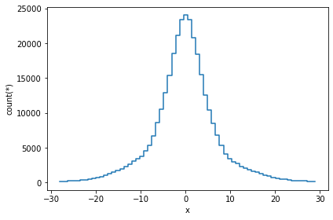

```python
df.plot1d(df.x, limits='99.7%');
```

A slighly more complication visualization, is to plot not the counts, but a different statistic for that bin. In most cases, passing the `what='<statistic>(<expression>)` argument will do, where `<statistic>` is any of the statistics mentioned in the list above, or in the API docs.

The same applies for 2-D plotting.

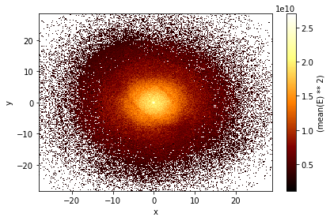

```python
df.plot(df.x, df.y, what=vaex.stat.mean(df.E)**2, limits='99.7%');
```

### Advanced Plotting

Lets say we would like to see two plots next to eachother. To achieve this we can pass a list of expression pairs.

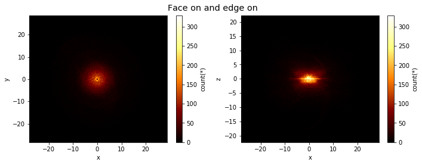

```python
df.plot([["x", "y"], ["x", "z"]], limits='99.7%',
        title="Face on and edge on", figsize=(10,4));
```

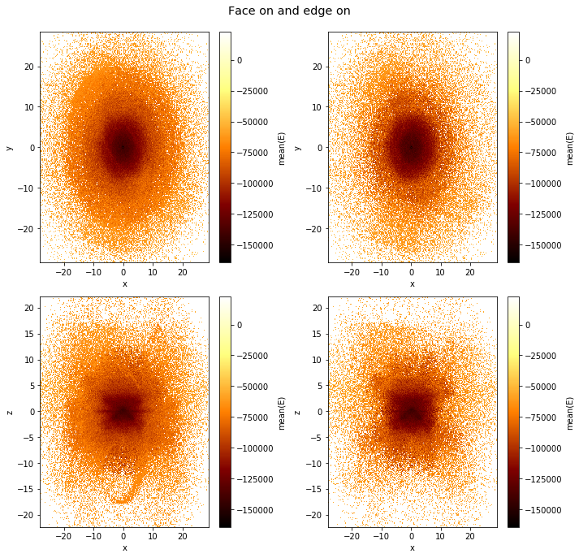

```python
df.plot([["x", "y"], ["x", "z"]],
        limits='99.7%',
        what=vaex.stat.mean(df.E),
        selection=[None, df.Lz < 0],
        visual=dict(column='selection'),
        title="Face on and edge on", figsize=(10,10));
```

## Joining

Joining in Vaex is similar to Pandas, except the data will no be copied. Internally an index array is kept for each row on the left DataFrame, pointing to the right DataFrame, requiring about 8GB for a billion row $10^9$ dataset. Lets start with 2 small DataFrames, `df1` and `df2`:

```python
a = np.array(['a', 'b', 'c'])
x = np.arange(1,4)
df1 = vaex.from_arrays(a=a, x=x)
df1
```

| # | a | x |
| --- | --- | --- |
| *0* | a | 1 |
| *1* | b | 2 |
| *2* | c | 3 |

```python
b = np.array(['a', 'b', 'd'])
y = x**2
df2 = vaex.from_arrays(b=b, y=y)
df2
```

| # | b | y |
| --- | --- | --- |
| *0* | a | 1 |
| *1* | b | 4 |
| *2* | d | 9 |

The default join, is a 'left' join, where all rows for the left DataFrame (`df1`) are kept, and matching rows of the right DataFrame (`df2`) are added. We see that for the columns b and y, some values are missing, as expected.

```python
df1.join(df2, left_on='a', right_on='b')
```

| # | a | x | b | y |
| --- | --- | --- | --- | --- |
| *0* | a | 1 | a | 1 |
| *1* | b | 2 | b | 4 |
| *2* | c | 3 | -- | -- |

A 'right' join, is basically the same, but now the roles of the left and right label swapped, so now we have some values from columns x and a missing.

```python
df1.join(df2, left_on='a', right_on='b', how='right')
```

| # | b | y | a | x |
| --- | --- | --- | --- | --- |
| *0* | a | 1 | a | 1 |
| *1* | b | 4 | b | 2 |
| *2* | d | 9 | -- | -- |

## Group-by

With Vaex one can also do fast group-by aggregations. The output is Vaex DataFrame. Let us see few examples.

```python
import vaex
animal = ['dog', 'dog', 'cat', 'guinea pig', 'guinea pig', 'dog']
age = [2, 1, 5, 1, 3, 7]
cuteness = [9, 10, 5, 8, 4, 8]
df_pets = vaex.from_arrays(animal=animal, age=age, cuteness=cuteness)
df_pets
```

| # | animal | age | cuteness |
| --- | --- | --- | --- |
| *0* | dog | 2 | 9 |
| *1* | dog | 1 | 10 |
| *2* | cat | 5 | 5 |
| *3* | guinea pig | 1 | 8 |
| *4* | guinea pig | 3 | 4 |
| *5* | dog | 7 | 8 |

The syntax for doing group-by operations is virtually identical to that of Pandas. Note that when multiple aggregations are passed to a single column or expression, the output colums are appropriately named.

```python
df_pets.groupby(by='animal').agg({'age': 'mean',
                                  'cuteness': ['mean', 'std']})
```

| # | animal | age | cuteness_mean | cuteness_std |
| --- | --- | --- | --- | --- |
| *0* | dog | 3.33333 | 9 | 0.816497 |
| *1* | cat | 5 | 5 | 0 |
| *2* | guinea pig | 2 | 6 | 2 |

Vaex supports a number of aggregation functions:

- vaex.agg.count: Number of elements in a group
- vaex.agg.first: The first element in a group
- vaex.agg.max: The largest value in a group
- vaex.agg.min: The smallest value in a group
- vaex.agg.sum: The sum of a group
- vaex.agg.mean: The mean value of a group
- vaex.agg.std: The standard deviation of a group
- vaex.agg.var: The variance of a group
- vaex.agg.nunique: Number of unique elements in a group

A powerful feature of the aggregation functions in Vaex is that they support selections. This gives us the flexibility to make selections while aggregating. For example, let's calculate the mean cuteness of the pets in this example DataFrame, but separated by age.

```python
df_pets.groupby(by='animal',
                agg={'mean_cuteness_old': vaex.agg.mean('cuteness', selection='age>=5'),
                     'mean_cuteness_young': vaex.agg.mean('cuteness', selection='~(age>=5)')})
```

| # | animal | mean_cuteness_old | mean_cuteness_young |
| --- | --- | --- | --- |
| *0* | dog | 8 | 9.5 |
| *1* | cat | 5 | nan |
| *2* | guinea pig | nan | 6 |

## String processing

String processing is similar to Pandas, except all operations are performed lazily, multithreaded, and faster (in C++). Check the API docs for more examples.

```python
import vaex
text = ['Something', 'very pretty', 'is coming', 'our', 'way.']
df = vaex.from_arrays(text=text)
df
```

| # | text |
| --- | --- |
| *0* | Something |
| *1* | very pretty |
| *2* | is coming |
| *3* | our |
| *4* | way. |

```python
df.text.str.title().str.replace('et', 'ET')
```

```
Expression = str_replace(str_title(text), 'et', 'ET')
Length: 5 dtype: str (expression)
---------------------------------
0    SomEThing
1  Very PrETty
2    Is Coming
3          Our
4         Way.
```

```python
df.text.str.contains('e')
```

```
Expression = str_contains(text, 'e')
Length: 5 dtype: bool (expression)
----------------------------------
0   True
1   True
2  False
3  False
4  False
```

## Just-In-Time compilation

Let us start with a function that calculates the angular distance between two points on a surface of a sphere. The input of the function is a pair of 2 angular coordinates, in radians.

```python
import vaex
import numpy as np
# From http://pythonhosted.org/pythran/MANUAL.html
def arc_distance(theta_1, phi_1, theta_2, phi_2):
    """
    Calculates the pairwise arc distance
    between all points in vector a and b.
    """
    temp = (np.sin((theta_2-2-theta_1)/2)**2
           + np.cos(theta_1)*np.cos(theta_2) * np.sin((phi_2-phi_1)/2)**2)
    distance_matrix = 2 * np.arctan2(np.sqrt(temp), np.sqrt(1-temp))
    return distance_matrix

nytaxi = vaex.open('s3://vaex/taxi/yellow_taxi_2009_2015_f32.hdf5?anon=true')
nytaxi.set_active_fraction(0.2)
```

This computation uses quite some heavy mathematical operations, and since it's (internally) using Numpy arrays, also uses quite some temporary arrays. We can optimize this calculation by doing a Just-In-Time compilation, based on [numba](https://numba.pydata.org/), [pythran](https://pythonhosted.org/pythran/), or if you happen to have an NVIDIA graphics card [cuda](https://developer.nvidia.com/cuda-zone). Choose whichever gives the best performance or is easiest to install.

```python
nytaxi['arc_distance_jit'] = nytaxi.arc_distance.jit_numba()
# nytaxi['arc_distance_jit'] = nytaxi.arc_distance.jit_pythran()
# nytaxi['arc_distance_jit'] = nytaxi.arc_distance.jit_cuda()
```

[output not shown]

```python
%%time
nytaxi.mean(nytaxi.arc_distance_jit)
```

```
CPU times: user 25.7 s, sys: 330 ms, total: 26 s
Wall time: 2.31 s
```

```
array(1.9999328)
```

## Extending Vaex

Vaex can be extended using several mechanisms.

### Adding functions

Use the vaex.register_function decorator API to add new functions.

```python
import vaex
import numpy as np
@vaex.register_function()
def add_one(ar):
    return ar+1
```

By default (passing `on_expression=True`), the function is also available as a method on Expressions, where the expression itself is automatically set as the first argument (since this is a quite common use case).

```python
df.x.add_one()
```

[output not shown]

```python
@vaex.register_function(on_expression=False)
def addmul(a, b, x, y):
    return a*x + b * y
```

```python
df = vaex.from_arrays(x=np.arange(4))
df['y'] = df.x**2
df.func.addmul(2, 3, df.x, df.y)
```

```
Expression = addmul(2, 3, x, y)
Length: 4 dtype: int64 (expression)
-----------------------------------
0   0
1   5
2  16
3  33
```

### Adding DataFrame accessors

When adding methods that operate on Dataframes, it makes sense to group them together in a single namespace.

```python
@vaex.register_dataframe_accessor('scale', override=True)
class ScalingOps(object):
    def __init__(self, df):
        self.df = df

    def mul(self, a):
        df = self.df.copy()
        for col in df.get_column_names(strings=False):
            if df[col].dtype:
                df[col] = df[col] * a
        return df

    def add(self, a):
        df = self.df.copy()
        for col in df.get_column_names(strings=False):
            if df[col].dtype:
                df[col] = df[col] + a
        return df
```

```python
df.scale.add(1)
```

[output not shown]

# The escape hatch: apply

In case a calculation cannot be expressed as a Vaex expression, one can use the `apply` method as a last resort. This can be useful if the function you want to apply is written in pure Python, a third party library, and is difficult or impossible to vectorize.

We think apply should only be used as a last resort, because it needs to use multiprocessing (which spawns new processes) to avoid the Python Global Interpreter Lock (GIL) to make use of multiple cores. This comes at a cost of having to transfer the data between the main and child processes.

Here is an example which uses the `apply` method:

```python
import vaex

def slow_is_prime(x):
    return x > 1 and all((x % i) != 0 for i in range(2, x))

df = vaex.from_arrays(x=vaex.vrange(0, 100_000, dtype='i4'))
# you need to explicitly specify which arguments you need
df['is_prime'] = df.apply(slow_is_prime, arguments=[df.x])
df.head(3)
```

| # | x | is_prime |
| --- | --- | --- |
| *0* | 0 | False |
| *1* | 1 | False |
| *2* | 2 | True |

```python
# both of these are equivalent
df['is_prime'] = df.apply(slow_is_prime, arguments=[df.x])
# but this form only works for a single argument
df['is_prime'] = df.x.apply(slow_is_prime)
```

```python
# will transfer the data to child processes, and execute the ** operation in Python for each element
df['y_slow'] = df.x.apply(lambda x: x**2)
```

```python
# bad idea: it will transfer the data to the child process, where it will be executed in vectorized form
df['y_slow_vectorized'] = df.x.apply(lambda x: x**2, vectorize=True)
```

```python
# bad idea: same performance as just dy['y'], but we lose the information about what was done
df['y_fast'] = df.x.apply(lambda x: x**2, vectorize=True, multiprocessing=False)
```